# HW 2: Предсказание отклика различных групп респондентов на новую макркетинговую кампанию

Пясецкая Вероника, vvpyasetskaya

## Задача

Спрогнозировать, какие группы респондентов окажутся наиболее восприимчивы к новой маркетинговой кампании, проводимой в сети магазинов. Иными словами, определить целевую аудиторию предстоящей кампании, выявив закономерности в реакции респондентов и предсказав их отклик на неё. Выводы данного исследования могут быть использованы для более точечного и предметного воздействия на клиента с помощью маркетинговых инструментов.

### Загрузка данных и преобразование

```r
marketing = read.csv("~/shared/minor2_2022/1-Intro/hw2/marketing_campaign.csv")
source("~/shared/minor2_2022/1-Intro/lab09-gini-trees/compute_gini.R")
library(dplyr)
library(rpart.plot)
library(rpart)
library(lubridate)
library(ggplot2)
library(coin)
library(skimr)
```

В процессе первичной обработки данных перемнные типа character и ряд числовых переменных были преобразованы в факторные. На дальнейших этапах анализа была удалена переменная ID.Так же были выявлены и удалены наблюдения имеющие неизвестные значения в важной для исследования переменной Income. Из наблюдений по переменным Age и Income были удалены выбросы, так же по переменной Marital_Status были удалены ответы “YOLO” и “Absurd”. Переменная Dt_Customer была преобразована в дату вида: день-месяц-год, и с её помощью была создана новая переменная Age (возраст респондентов). Кроме того, при расмотрении Вопроса №6 была создана переменная food_percent, представляющая долю дохода, которую респондент тратит на продукты питания.

```r
marketing = marketing %>% filter(!(is.na(marketing$Dt_Customer)))
marketing = marketing %>% mutate_if(is.character, as.factor)
marketing$Response = as.factor(marketing$Response)
marketing$AcceptedCmp = as.factor(marketing$AcceptedCmp)
marketing$Complain = as.factor(marketing$Complain)
marketing = marketing %>% filter(!is.na(Income))
```

### Исследовательские вопросы и тесты

*Проведём разведовательный анализ*

Выясним, как распределены клиенты по возрасту

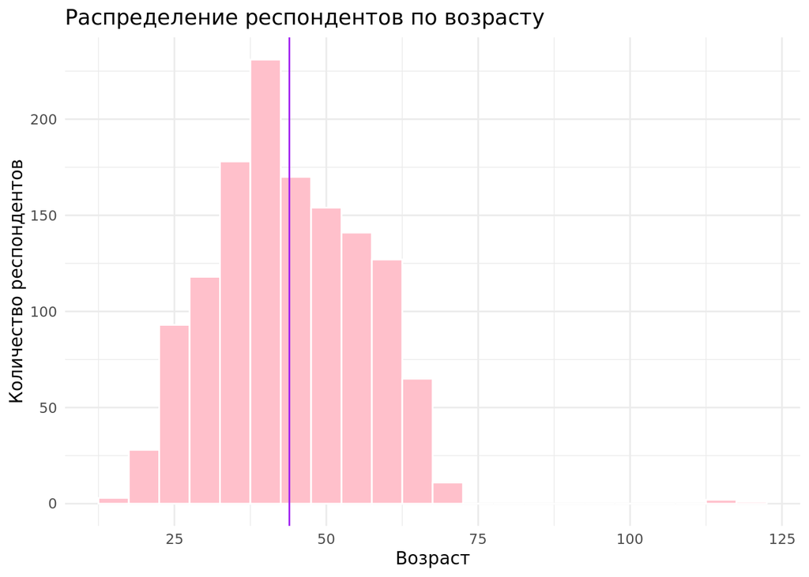

```r
marketing = marketing %>% mutate(date = dmy(marketing$Dt_Customer))
marketing = marketing %>% mutate(date = ymd(marketing$date))
marketing = marketing %>% mutate(year = year(marketing$date))
marketing = marketing %>% mutate(Age = marketing$year - marketing$Year_Birth)
marketing = marketing %>% select(-date,-year,-Dt_Customer)
ggplot(marketing) + geom_histogram(aes(x = Age), color = "white",fill = "pink",binwidth = 5) + geom_vline(aes(xintercept = mean(Age)), color = "purple") +
  xlab("Возраст") +
  ylab("Количество респондентов") +
  ggtitle("Распределение респондентов по возрасту") +
  theme_minimal()
```

По семейному статусу?

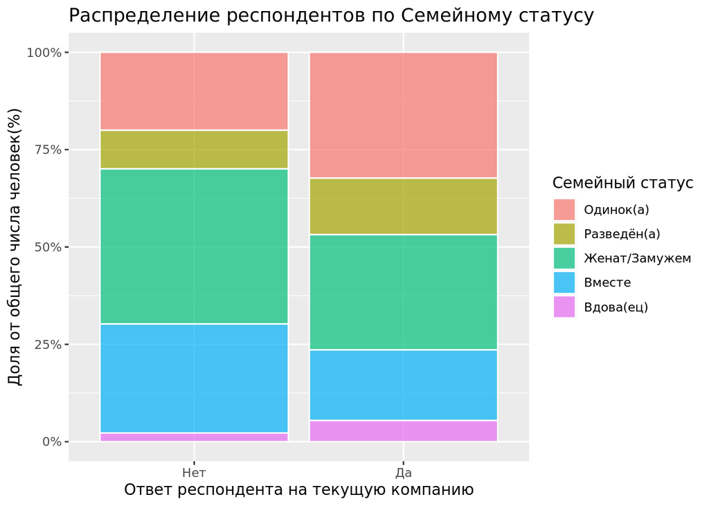

```r
marketing = marketing %>% filter(Marital_Status != "YOLO", Marital_Status != "Absurd" )
levels(marketing$Marital_Status) = c(" ","Одинок(a)","Разведён(a)","Женат/Замужем","Одинок(a)","Вместе","Вдова(ец)"," ")
ggplot(marketing) + geom_bar(aes(x = Response,fill = marketing$Marital_Status),position = "fill",color = "white", alpha = 0.7)+
  scale_fill_discrete(name="Семейный статус")+
  scale_x_discrete(breaks=c(0,1),label=c("Нет","Да")) +
  xlab("Ответ респондента на текущую компанию") +
  ylab("Доля от общего числа человек(%)") +
  ggtitle("Распределение респондентов по Семейному статусу")+
  scale_y_continuous(labels = scales::percent_format())
```

Из графика видно, что распределение по семейному статусу неравномерно. Среди откликнувшихся на кампанию больше Одиноких, Разведённых и Вдовцов и меньше Женатых/Состоящих в отношениях (Вместе) людей.

Теперь мы имеем представление о демографическом распределении респондентов. Сформулируем вопросы и изучим зависимости между переменными подробней.

*Вопрос №1:* Зависит ли Ответ на кaмпанию от Возраста респондента?

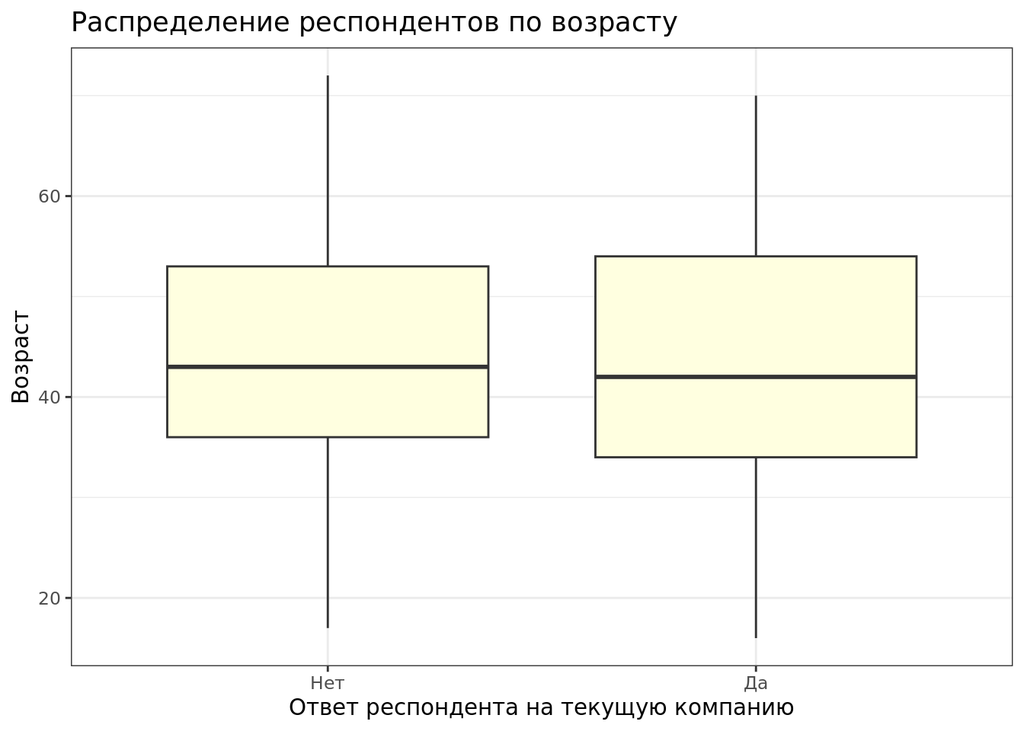

```r
marketing = marketing %>% filter (Age != 121, Age !=  114, Age !=  113)
ggplot(marketing) + geom_boxplot(aes(x = marketing$Response,y = Age),fill="light yellow") +
  scale_x_discrete(breaks=c(0,1),label=c("Нет","Да")) +
  xlab("Ответ респондента на текущую компанию") +
  ylab("Возраст") +
  ggtitle("Распределение респондентов по возрасту")+
  theme_bw()
```

```r
mean_age = marketing %>% group_by(Response) %>% summarise(mean(Age))
```

```r
table_age = marketing %>% group_by(Response) %>% summarise(mean_age = mean(Age))
dif_age = round(abs(table_age$mean_age[2] - table_age$mean_age[1]),2)
```

*Итог:* По графику можно сказать, что разница между средним возрастом обеих групп, составляющая меньше 1 года, визуально незначительна.

Сформулируем гипотезы и убедимся с помощью теста

`H0:` Средний возраст людей откликнувшихся на текущую компанию респондентов не отличается от среднего возраста не откликнувшихся

`H1:` Существует разница в среднем возрасте людей откликнувшихся и не откликнувшихся на компанию

Переменная Age имеет распределение близкое к нормальному, используем t-test

```r
t.test(Age ~ Response,data = marketing)
```

```
##
##  Welch Two Sample t-test
##
## data:  Age by Response
## t = 0.76868, df = 539.52, p-value = 0.4424
## alternative hypothesis: true difference in means between group 0 and group 1 is not equal to 0
## 95 percent confidence interval:
##  -0.9187522  2.1000272
## sample estimates:
## mean in group 0 mean in group 1
##        43.92901        43.33837
```

*Вывод:* На уровне значимости 0.05 статистически значимой разницы не обнаружено. Мы не можем отвергнуть H0.

*Вопрос №2:* Действительно ли люди, состоящие в отношениях, реже отвечают на кампанию, чем те, у кого нет партнёра?

При демографическом анализе было выявлено, что среди откликнувшихся на кампанию больше Одиноких, Разведённых и Вдовцов и меньше Женатых/Состоящих в отношениях (Вместе) людей. Таким образом, попробуем разделить их на две группы: В отношениях / Не в отношениях и посмотреть на разницу:

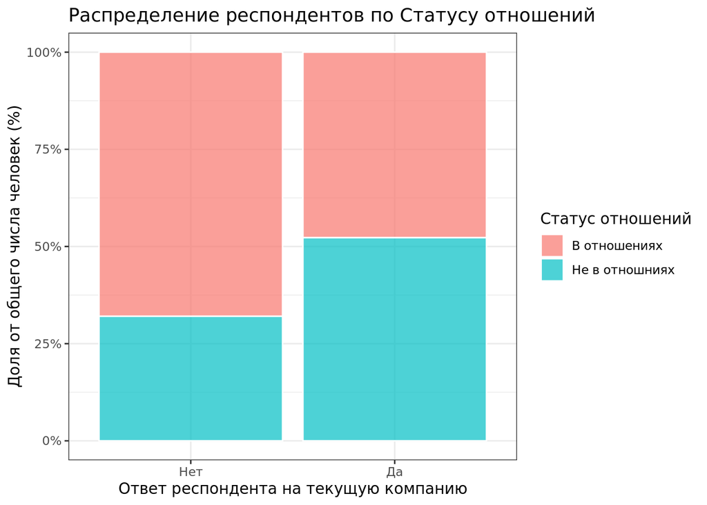

```r
marketing = marketing %>% mutate(Relationships = case_when(Marital_Status == "Женат/Замужем"~ "В отношениях", Marital_Status == "Вместе" ~ "В отношениях", T ~ "Не в отношниях"))
marketing$Relationships = as.factor(marketing$Relationships)

ggplot(marketing) + geom_bar(aes(x = Response,fill = marketing$Relationships),position = "fill",color = "white", alpha = 0.7)+
  scale_fill_discrete(name="Статус отношений")+
  scale_x_discrete(breaks=c(0,1),label=c("Нет","Да")) +
  xlab("Ответ респондента на текущую компанию") +
  ylab("Доля от общего числа человек (%)") +
  ggtitle("Распределение респондентов по Статусу отношений")+
  scale_y_continuous(labels = scales::percent_format()) +
  theme_bw()
```

Различие между группами стало намного заметней, посчитаем разницу

```r
table_rel = table(marketing$Response,marketing$Relationships)
res_no_rel_no = (table_rel[2,2]/(sum(table_rel[2,1],table_rel[2,2])))*100
res_yes_rel_no = (table_rel[1,2]/(sum(table_rel[1,1],table_rel[1,2])))*100
dif_rel = abs(round(res_no_rel_no - res_yes_rel_no))
```

*Итог:* Выявленный размер эффекта составляет 20%

`H0:` Разницы между Статусом отношений положительно и отрицательно ответивших на компанию респондентов не сущесвтует

`H1:` Существует разница между Статусом отношений положительно и отрицательно ответивших на компанию респондентов

Для двух категориальных переменных используем тест Хи-квадрат:

```r
chisq.test(marketing$Relationships, marketing$Response)
```

```
##
##  Pearson's Chi-squared test with Yates' continuity correction
##
## data:  marketing$Relationships and marketing$Response
## X-squared = 42.529, df = 1, p-value = 6.966e-11
```

*Вывод:* p-value достаточно мало. Разница между долями респондентов статистически значима (на уровне значимости 0.05). Мы можем отвергнуть H0 и использовать переменную Relationships подбирая разбиения при построении модели.

*Вопрос №3:* Правда ли, что люди положительно ответившие на предыдущую кaмпанию охотней откликаются на текущую?

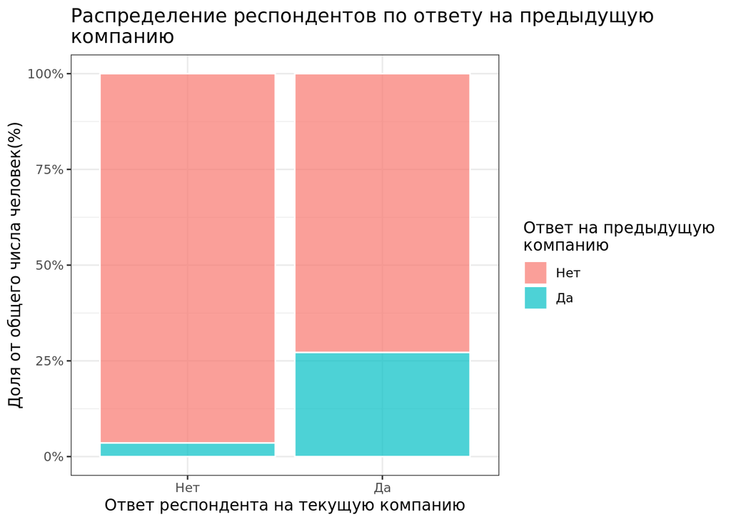

```r
ggplot(marketing) + geom_bar(aes(x = marketing$Response,fill = AcceptedCmp),position = "fill",color = "white", alpha = 0.7,) +
  scale_fill_discrete(breaks=c(0,1),label=c("Нет","Да"),name = "Ответ на предыдущую\nкомпанию") +
  scale_x_discrete(breaks=c(0,1),label=c("Нет","Да")) +
  xlab("Ответ респондента на текущую компанию") +
  ylab("Доля от общего числа человек(%)") +
  ggtitle("Распределение респондентов по ответу на предыдущую\nкомпанию")+
  scale_y_continuous(labels = scales::percent_format()) +
  theme_bw()
```

```r
table_acc = table(marketing$Response ,marketing$AcceptedCmp == 1)
dif_acc = ((table_acc[2,2]/sum(table_acc[2,1],table_acc[2,2])) - table_acc[1,2]/sum(table_acc[1,1],table_acc[1,2]))*100
dif_acc = round(dif_acc)
```

*Итог:* Вычисленная явным образом разница составляет 24 %

Проверим с помощью теста

`H0:` Разница между долями респондентов принявших предложение в предыдущую компанию, среди положительно и отрицательно ответивших на текущую компанию равна 0

`H1:` Разница между долями респондентов принявших предложение в предыдущую компанию, среди положительно и отрицательно ответивших на текущую компанию не равна 0

```r
ch = chisq.test(marketing$Response, marketing$AcceptedCmp)
ch
```

```
##
##  Pearson's Chi-squared test with Yates' continuity correction
##
## data:  marketing$Response and marketing$AcceptedCmp
## X-squared = 158.48, df = 1, p-value < 2.2e-16
```

*Вывод:* p-value очень мало. На уровне значимости 0.05 существует статистически значимая разница между долями респондентов. Мы можем отвергнуть H0 и использовать переменную AcceptedCmp подбирая разбиения при построении модели.

*Вопрос №4:* Действительно ли чем меньше времени прошло с последней покупки, совершённой респондентом, тем охотней он принимает участие в текущей кaмпании?

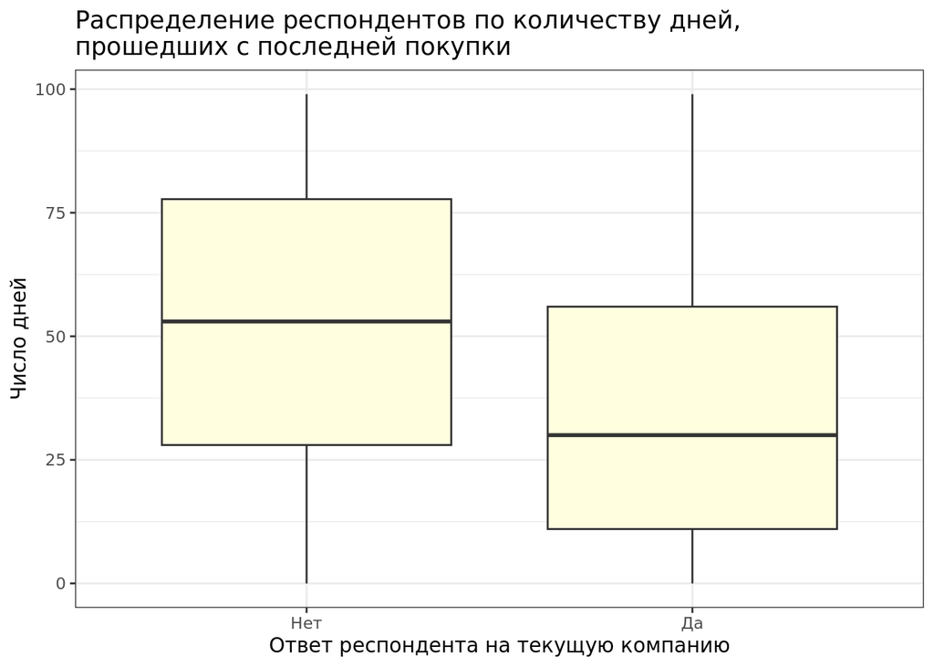

```r
ggplot(marketing) + geom_boxplot(aes(x = Response,y = Recency),fill="light yellow") +
  scale_x_discrete(breaks=c(0,1),label=c("Нет","Да")) +
  xlab("Ответ респондента на текущую компанию") +
  ylab("Число дней") +
  ggtitle("Распределение респондентов по количеству дней,\nпрошедших с последней покупки")+
  theme_bw()
```

Визуально разница достаточно заметна. Если точнее:

```r
table_rec = marketing %>% group_by(Response) %>% summarise(mean_rec = mean(Recency))
dif_rec = round(abs(table_rec$mean_rec[2] - table_rec$mean_rec[1]))
table_rec_med = marketing %>% group_by(Response) %>% summarise(median_rec = median(Recency))
dif_rec_med = round(abs(table_rec_med$median_rec[2] - table_rec_med$median_rec[1]))
```

*Итог:* Разница в среднем количестве дней, прошедших с последней покупки составляет 17 дней. Разница медианных значений составила 23 дня.

`H1:`Разницы между количестовом дней, прошедших с последней покупки среди согласившихся и отказавшихся от участия в компании репондентов не существует

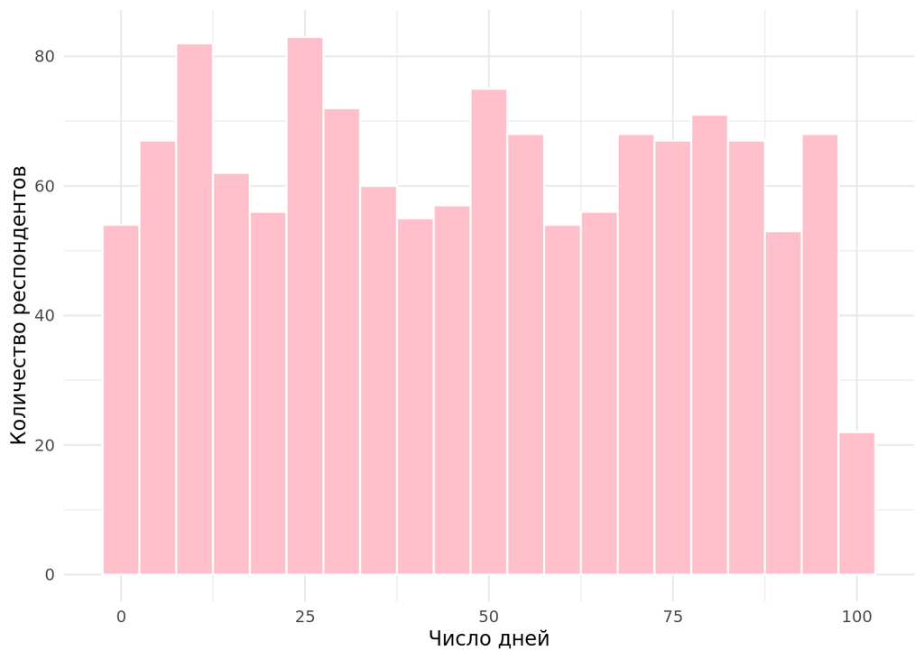

```r
ggplot(marketing) + geom_histogram(aes(x = Recency), color = "white",fill = "pink",binwidth = 5)+   xlab("Число дней") +
  ylab("Количество респондентов") +
  theme_minimal()
```

Распределение не нормальное, используем тест перестановок

```r
independence_test(Recency ~ Response,data = marketing)
```

```
##
##  Asymptotic General Independence Test
##
## data:  Recency by Response (0, 1)
## Z = 9.1058, p-value < 2.2e-16
## alternative hypothesis: two.sided
```

*Вывод:* Между количеством прошедших с последней покупки дней существует статистически значимая разница (на уровне значимости 0.05). Мы можем отвергуть H0 и учесть переменную Recency при построении модели.

*Вопрос №5:* Участвуют ли чаще в текущей кaмпании клиенты с бОльшим доходом?

Удалим выбросы сильно влияющие на результат

```r
marketing = marketing %>% filter(Income < 150000)
```

Посмотрим на распределение

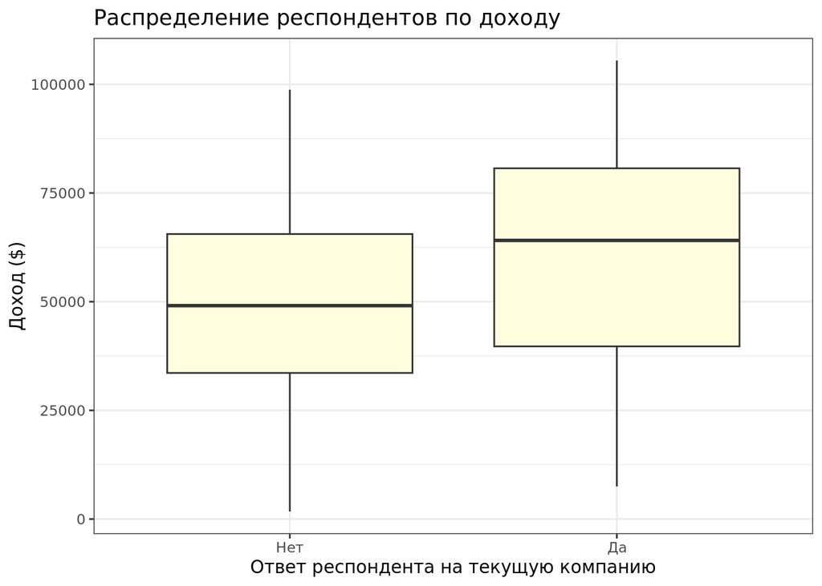

```r
ggplot(marketing) + geom_boxplot(aes(x = Response,y = Income),fill="light yellow") +
  scale_x_discrete(breaks=c(0,1),label=c("Нет","Да")) +
  xlab("Ответ респондента на текущую компанию") +
  ylab("Доход ($)") +
  ggtitle("Распределение респондентов по доходу")+
  theme_bw()
```

```r
table_inc = marketing %>% group_by(Response) %>% summarise(mean_inc = mean(Income))
dif_inc = round(abs(table_inc$mean_inc[2] - table_inc$mean_inc[1]))
table_inc_med = marketing %>% group_by(Response) %>% summarise(median_inc = median(Income))
dif_inc_med = round(abs(table_inc_med$median_inc[2] - table_inc_med$median_inc[1]))
```

*Итог:* Выявлена разница среднего и медианного дохода, составляющая 10 847$ и 14 998$ соответственно

`H0:` Разница в размере дохода согласившихся и отказавшихся от участия в компании респондентов равна 0

`H1:`Разница в размере дохода согласившихся и отказавшихся от участия в компании респондентов не равна 0

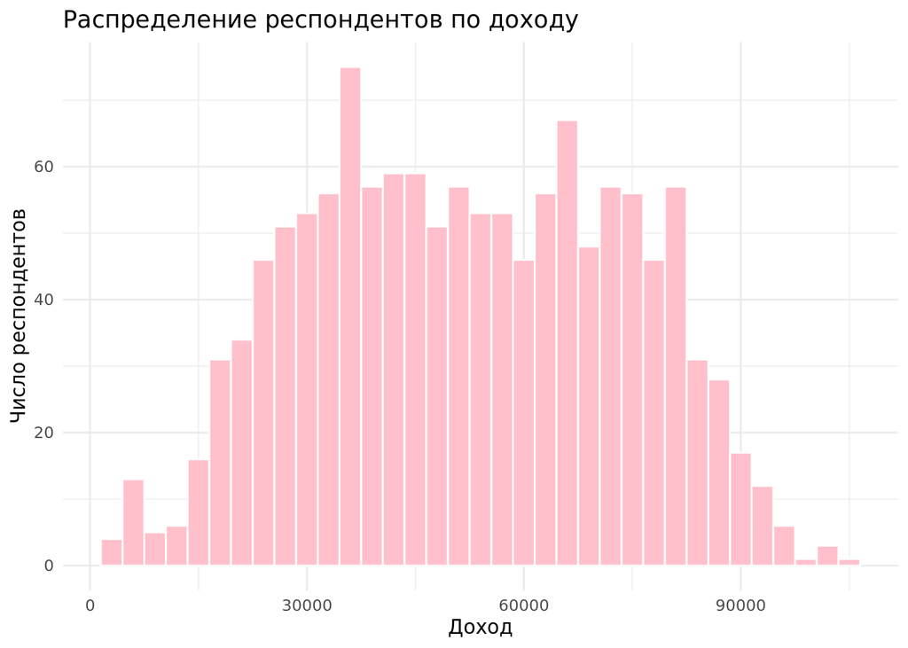

```r
ggplot(marketing) + geom_histogram(aes(x = Income),color = "white",fill = "pink",binwidth = 3000) + xlab("Доход") +
  ylab("Число респондентов") +
  ggtitle("Распределение респондентов по доходу")+
  theme_minimal()
```

Распределение визуально неочевидно, используем тест перестановок

```r
independence_test(Income ~ Response, data = marketing)
```

```
##
##  Asymptotic General Independence Test
##
## data:  Income by Response (0, 1)
## Z = -7.9581, p-value = 1.747e-15
## alternative hypothesis: two.sided
```

*Вывод:* Разница в размере дохода между двумя группами существет и является статистически значимой (на уровне значимости 0.05). Мы можем отвернуть H0 и использовать переменную Income при построении модели. Однако, возможно более справедливой для оценки переменной была бы доля дохода, потраченного непосредственно на продукты питания. Проверим предположение

*Вопрос №6:* Связана ли доля дохода которую репсондент тратит на продукты питания с его ответом на предложение в текущей кaмпании?

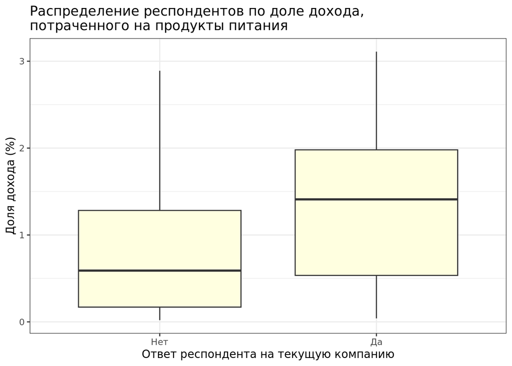

```r
marketing = marketing %>% mutate(food_expenses = (marketing$MntWines + marketing$MntFruits + marketing$MntMeatProducts + marketing$MntFishProducts + marketing$MntSweetProducts))
food_percent = round((marketing$food_expenses/marketing$Income)*100,2)
marketing = marketing %>% mutate(food_percent)
marketing = marketing %>% select(-food_expenses)
marketing = marketing %>% filter(!is.na(food_percent))

ggplot(marketing) + geom_boxplot(aes(x = Response, y = food_percent),fill="light yellow") +
  scale_x_discrete(breaks=c(0,1),label=c("Нет","Да")) +
  xlab("Ответ респондента на текущую компанию") +
  ylab("Доля дохода (%)") +
  ggtitle("Распределение респондентов по доле дохода,\nпотраченного на продукты питания") +
  theme_bw()
```

```r
table_food = marketing %>% group_by(Response) %>% summarise(mean_food = mean(food_percent))
dif_food = round(abs(table_food$mean_food[2] - table_food$mean_food[1]),2)
table_food_med = marketing %>% group_by(Response) %>% summarise(median_food = median(food_percent))
dif_food_med = round(abs(table_food_med$median_food[2] - table_food_med$median_food[1]),2)
```

*Итог:* Разница в средней и медианной доле дохода, уходящей на продукты составила 0.52% и 0.82% соответственно

`H1:` Разницы в доле дохода, потраченного на продукты питания для респондентов ответивших и не ответивших на текщую компанию не существует

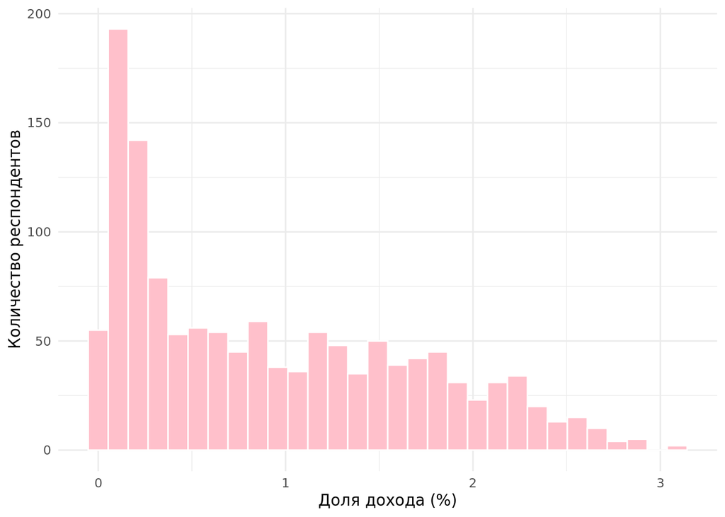

```r
ggplot(marketing) + geom_histogram(aes(x = food_percent),color = "white",fill = "pink") +          xlab("Доля дохода (%)") +
  ylab("Количество респондентов") +
  theme_minimal()
```

Используем тест перестановок

```r
independence_test(food_percent ~ Response, data = marketing )
```

```
##
##  Asymptotic General Independence Test
##
## data:  food_percent by Response (0, 1)
## Z = -10.765, p-value < 2.2e-16
## alternative hypothesis: two.sided
```

*Вывод:* Выявленна статистически знаимая разница (на уровне значимости 0.05) в доле дохода, потраченного на продукты питания между двумя группами. Следовательно, мы можем отвергнуть H0 и использовать эту переменную, как критерий разбиения.

Посмотрим на данные иначе

```r
compareGroups::compareGroups(Response ~ .,data = marketing) %>%
  compareGroups::createTable()
```

```
##
## --------Summary descriptives table by 'Response'---------
##
## ________________________________________________________
##                          0             1       p.overall
##                        N=980         N=331
## ¯¯¯¯¯¯¯¯¯¯¯¯¯¯¯¯¯¯¯¯¯¯¯¯¯¯¯¯¯¯¯¯¯¯¯¯¯¯¯¯¯¯¯¯¯¯¯¯¯¯¯¯¯¯¯¯
## ID                  5630 (3299)   5398 (3150)    0.252
## Year_Birth          1969 (11.5)   1969 (12.3)    0.724
## Education:                                      <0.001
##     2n Cycle        89 (9.08%)    22 (6.65%)
##     Basic           29 (2.96%)     2 (0.60%)
##     Graduation      509 (51.9%)   151 (45.6%)
##     Master          153 (15.6%)   56 (16.9%)
##     PhD             200 (20.4%)   100 (30.2%)
## Marital_Status:                                 <0.001
##     Одинок(a)       197 (20.1%)   107 (32.3%)
##     Разведён(a)     97 (9.90%)    48 (14.5%)
##     Женат/Замужем   392 (40.0%)   98 (29.6%)
##     Вместе          272 (27.8%)   60 (18.1%)
##     Вдова(ец)       22 (2.24%)    18 (5.44%)
## Income             49341 (20085) 60188 (23232)  <0.001
## Kidhome             0.48 (0.55)   0.34 (0.49)   <0.001
## Teenhome            0.55 (0.55)   0.31 (0.49)   <0.001
## Recency             52.3 (28.7)   35.3 (27.6)   <0.001
## MntWines             268 (307)     503 (429)    <0.001
## MntFruits           23.0 (36.4)   37.9 (45.9)   <0.001
## MntMeatProducts      141 (194)     295 (288)    <0.001
## MntFishProducts     33.7 (51.5)   51.4 (61.1)   <0.001
## MntSweetProducts    24.8 (39.2)   38.4 (46.2)   <0.001
## NumDealsPurchases   2.31 (1.72)   2.34 (2.11)    0.857
## NumWebPurchases     3.88 (2.67)   5.07 (2.57)   <0.001
## NumStorePurchases   5.71 (3.24)   6.08 (3.08)    0.063
## AcceptedCmp:                                    <0.001
##     0               945 (96.4%)   241 (72.8%)
##     1               35 (3.57%)    90 (27.2%)
## Complain:                                        1.000
##     0               971 (99.1%)   328 (99.1%)
##     1                9 (0.92%)     3 (0.91%)
## Age                 43.9 (11.6)   43.3 (12.3)    0.437
## Relationships:                                  <0.001
##     В отношениях    664 (67.8%)   158 (47.7%)
##     Не в отношниях  316 (32.2%)   173 (52.3%)
## food_percent        0.79 (0.69)   1.31 (0.82)   <0.001
## ¯¯¯¯¯¯¯¯¯¯¯¯¯¯¯¯¯¯¯¯¯¯¯¯¯¯¯¯¯¯¯¯¯¯¯¯¯¯¯¯¯¯¯¯¯¯¯¯¯¯¯¯¯¯¯¯
```

Перекосы в данных в основном соотствуют выявленным переменным, что позволяет подтвердить заключения сделанные выше

### Предсказание отклика на кампанию

Посчитаем насколько однородны по Ответам на компанию наши исходные данные

```r
gini_initial = marketing %>% count(Response) %>% mutate(prop = n/sum(n)) %>%
  summarise(round((1 - sum(prop^2)),2))
```

Для того, чтобы понять, насколько наши предсказания генерализируемы и распространимы на популяцию, разделим наблюдения на тренировочную и тестовую выборки. Построим разбиение по выявленным переменным на тренировочной выборке и проверим качество предсказания на тестовой

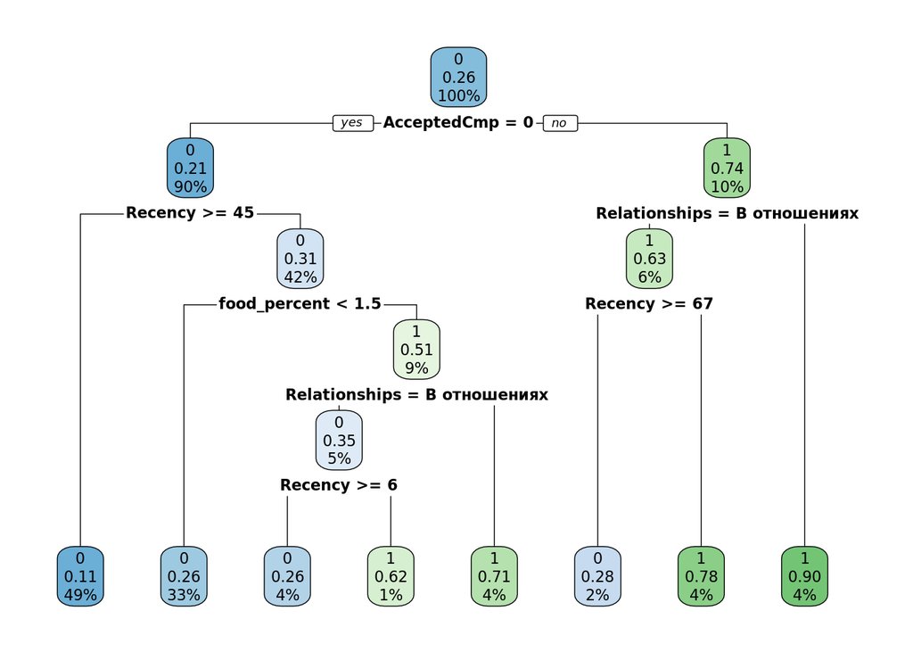

```r
set.seed(8)
market_train = marketing %>% sample_frac(0.8)
market_test = anti_join(marketing, market_train, by = 'ID') %>% select(-ID)
market_train = market_train %>% select(-ID)

my_train_tree = rpart(Response ~ Relationships + AcceptedCmp + Recency + Income + food_percent, method = "class", data = market_train)

rpart.plot(my_train_tree, extra = 106)
```

Обрежем дерево по cp

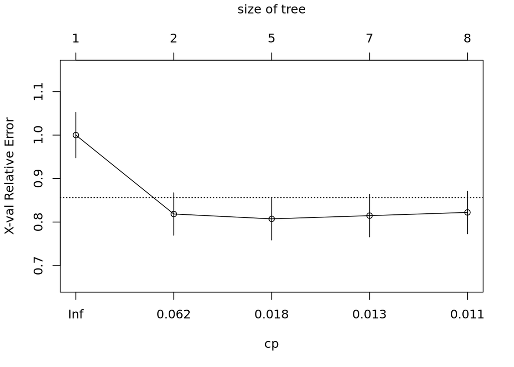

```r
plotcp(my_train_tree)
```

```r
#my_train_tree$cptable
```

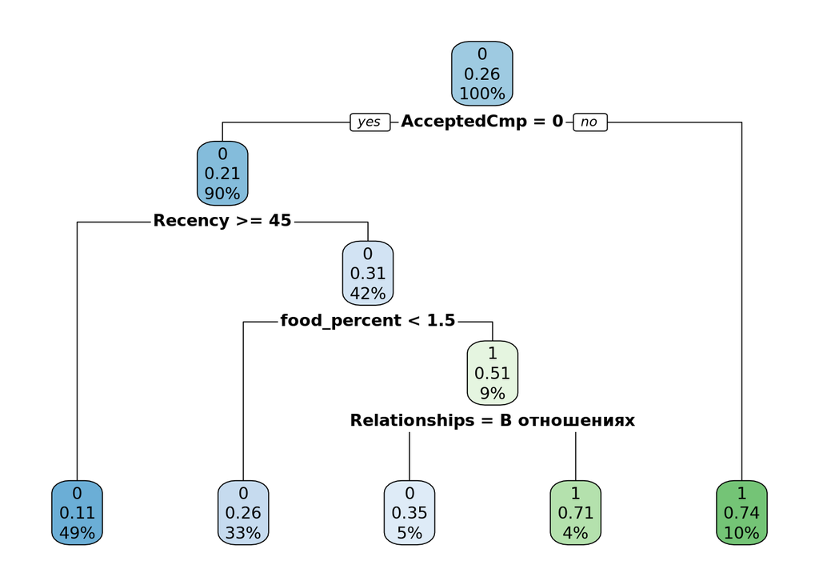

```r
my_train_tree = prune(my_train_tree,cp = 0.02098765)
rpart.plot(my_train_tree, extra = 106)
```

Проверим качество нашей модели на тренировочной выборке

```r
market_train = market_train %>% mutate(my_prediction = predict(my_train_tree,type="class",data = market_train))
t_train = table(truth = market_train$Response, estimate = market_train$my_prediction)
my_accuracy_train = round((t_train[1,1] + t_train[2,2])/sum(t_train),3)
my_gini_train = round(gini_split(data = market_train, real = Response, predicted = my_prediction),3)
```

*Точность на тренировочной модели составила:* 0.81 *Gini impurity:* = 0.31

Посчитаем качество насколько применима построенная модель для тестовой выборки

```r
set.seed(8)
market_test = market_test %>% mutate(my_prediction_test = predict(my_train_tree, market_test, type = "class"))

t_test = table(truth = market_test$Response, estimate = market_test$my_prediction_test)
my_accuracy_test = round((t_test[1,1] + t_test[2,2])/sum(t_test),3)
my_gini_test = round(gini_split(data = market_test, real = Response, predicted = my_prediction_test),3)
```

*Точность на тестовой модели составила:* 0.79 *Gini impurity:* = 0.32

*Вывод:* Дерево решений произвело разбиение по заданным переменным, несколько из которых были созданы вручную. Таким образом модель предсказала положительный отклик на кaмпанию двум группам: тем, кто откликнулся на предыдущую кaмпанию и тем, кто: не откликнулся на предыдущую кaмпанию, но совершил последнюю покупку менее 45 дней назад, тратит на продукты питания более 1.5 % от дохода и при этом не состоит в отношениях. Тем, кто не удовлетворил данным критериям модель предсказала отрицательный отклик на текущую кaмпанию. Итоговая модель демонстрирует достаточно высокую точность, как на тренировочной, так и на тестовой выборке, так же снижая исходный Gini Impurity.

Можно ли сделать нашу модель более точной и ещё больше снизить Gini Impurity? Определим наилучшее автоматическое разбиение по всем переменным для тенировочной выборки

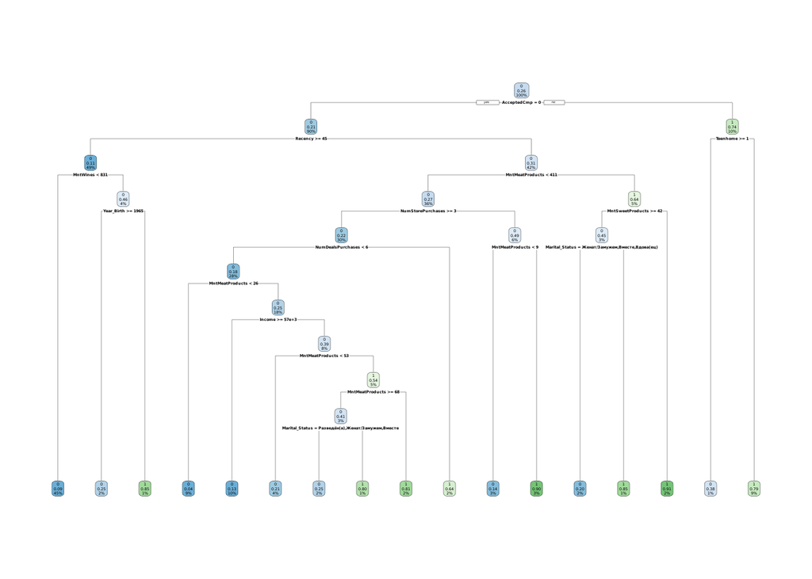

```r
set.seed(8)
market_train = market_train %>% select(-my_prediction)

auto_tree = rpart(Response ~ ., method = "class", data = market_train)
rpart.plot(auto_tree, extra = 106)
```

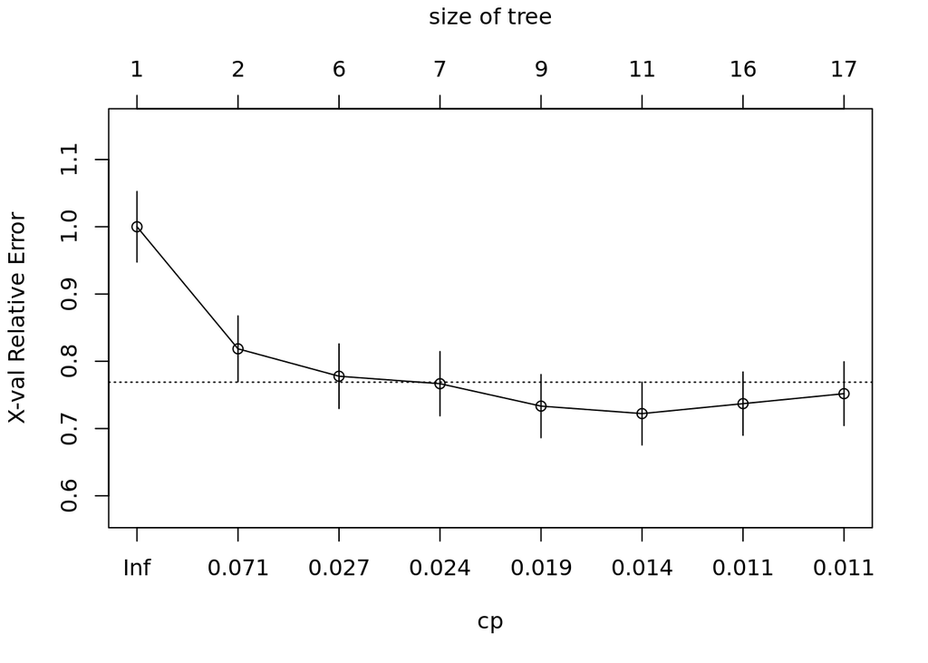

```r
#auto_tree$cptable
plotcp(auto_tree)
```

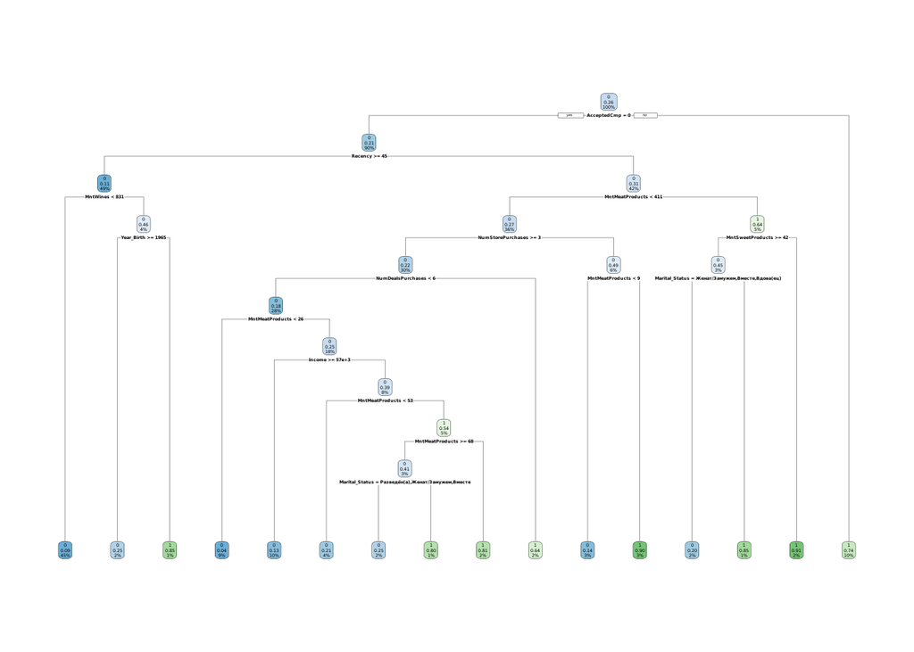

```r
auto_tree = prune(auto_tree, cp=0.01185185 )
rpart.plot(auto_tree)
```

```r
market_train = market_train %>% mutate(auto_prediction_train = predict(auto_tree,type="class",data = market_train))
t_a = table(truth = market_train$Response, estimate = market_train$auto_prediction_train)
auto_accuracy_train = (t_a[1,1] + t_a[2,2])/sum(t_a)
auto_gini_train = gini_split(data = market_train, real = Response, predicted = auto_prediction_train)
```

*Точность на тренировочной модели составила:* 0.87 *Gini impurity:* = 0.22

Проверим её качество на тестовой:

```r
set.seed(8)
market_test = market_test %>% select(-my_prediction_test)
market_test = market_test %>% mutate(auto_prediction_test = predict(auto_tree, market_test, type = "class"))
a_test = table(truth = market_test$Response, estimate = market_test$auto_prediction_test)
auto_accuracy_test = round((a_test[1,1] + a_test[2,2])/sum(a_test),3)
auto_gini_test = round(gini_split(data = market_test, real = Response, predicted = auto_prediction_test),3)
```

*Точность на тестовой модели составила:* 0.79 *Gini impurity:* = 0.3

*Вывод:* Дерево построенное по всем переменным вышло достаточно глубоким, использовалo многие из выявленных переменных, а так же несколько других. Точность на тренировочной выборке выше, а gini impurity ниже, чем у предыдущей модели. Однако, на тестовой выборке разница между двумя моделями в точности и чистоте практически незаметна. В то время как глубина дерева, построенного по заданным переменным заметно меньше, что говорит в пользу первой модели. Её мы и мудем использовать для итогового предсказания.

## Общие выводы

В результате проведённого анализа были выявлены группы респондентов, которые с наибольшей вероятностью откликнуться на новую маркетинговую компанию. Моя рекомендация при дальнейшем проведении кампании в других магазинах сети: уделить особое внимание целевой аудитории, состоящей в первую очередь из респондентов, откликнувшихся на предыдущую маркетинговую кампанию, а так же из одиноких клиентов, выделяющих больше 1.5 % своего дохода на продукты питания и совершивших в нашем магазине покупки не позже, чем за 45 дней до проведения кампании.